# Práctica 3. Regresión no paramétrica

Óscar Gómez Borzdynski

2/12/2020

# Primera parte

## Ejercicio 1

Los datos del fichero Datos-geyser.txt corresponden al día de la observación (primera columna), el tiempo medido en minutos (segunda columna $Y$ ) y el tiempo hasta la siguiente erupción (tercera columna $X$) del geyser Old Faithful en el parque norteamericano de Yellowstone.

### Apartado A

Representa gráficamente los datos, junto con el estimador de Nadaraya-Watson de la función de regresión de $Y$ sobre $X$.

### Solución

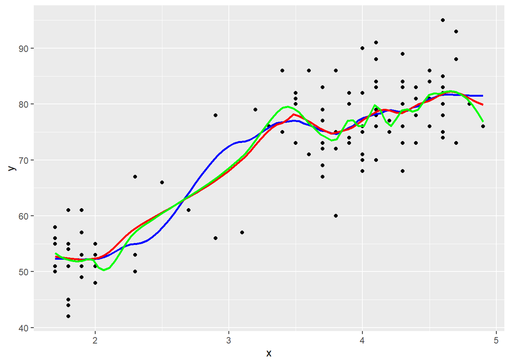

```r
geyser <- read.table('Datos-geyser.txt', header = TRUE)

df <- data.frame(y=geyser$Y, x=geyser$X)
ggplot(df, aes(x, y)) +
  geom_point() +
  geom_smooth(method = 'loess', se = FALSE, span = 0.25, method.args = list(degree=0), color="blue") +
  geom_smooth(method = 'loess', se = FALSE, span = 0.25, method.args = list(degree=1), color="red") +
  geom_smooth(method = 'loess', se = FALSE, span = 0.25, method.args = list(degree=2), color="green")
```

### Apartado B

Representa gráficamente los datos, junto con el estimador localmente lineal de la función de regresión de $Y$ sobre $X$.

### Solución

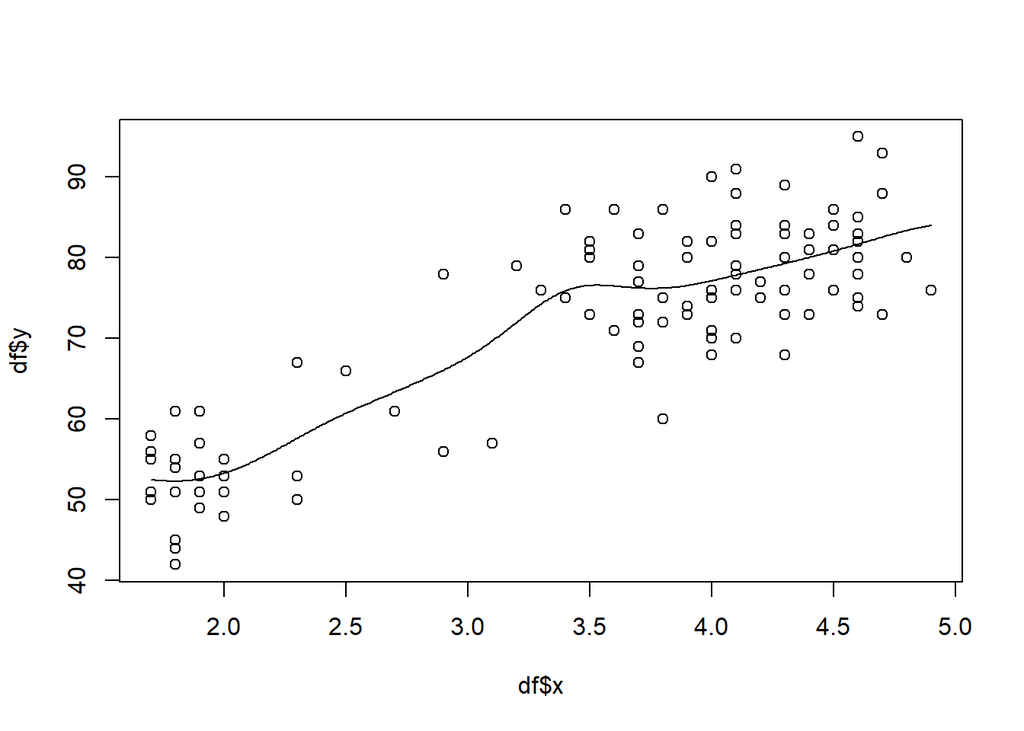

```r
geyser <- read.table('Datos-geyser.txt', header = TRUE)

df <- data.frame(y=geyser$Y, x=geyser$X)

ajuste <- with(df, locpoly(x, y, degree = 1, bandwidth = 0.25, gridsize = nrow(df)))

plot(df$x, df$y)
fit <- locpoly(df$x, df$y, bandwidth = 0.25)
lines(fit)
```

## Ejercicio 4

Se considera el siguiente modelo de regresión lineal múltiple:

$$Y_i = \beta_0 + \beta_1 x_{1i} + \beta_2 x_{2i} + \beta_3 x_{3i} + \epsilon_i,\quad \epsilon_i \equiv \mathcal N (0, \sigma^2),\quad i= 1,\dots, n$$

Se dispone de $n = 20$ observaciones con las que se ajustan todos los posibles submodelos del modelo (1), obteniéndose para cada uno de ellos las siguientes sumas de cuadrados de los errores (todos los submodelos incluyen un término independiente).

### Apartado A

Calcula la tabla de análisis de la varianza para el modelo (1) y contrasta a nivel $\alpha = 0,05$ la hipótesis nula $H_0 : \beta_1 = \beta_2 = \beta_3 = 0$.

### Solución

En este ejercicio he tenido un problema con la notación ya que en la tabla aparece SCE como suma de los errores al cuadrado en vez de como la suma de cuadrados explicada tratada en los apuntes. Por tanto voy a tomar el SCE de la tabla como el SCR de los apuntes (Suma de residuos al cuadrado).

Para contrastar la hipótesis voy a comparar el modelo correspondiente con un modelo reducido.

Comenzamos con la hipótesis donde ninguna de las variables del modelo es significativa para la regresión, para ello comparamos el modelo completo con el modelo reducido $M_0 = \beta_0$.

| Res.Df | RSS | Df | Sum of Sq | F | Pr(>F) |
| --- | --- | --- | --- | --- | --- |
| 19 | 42644 | NA | NA | NA | NA |
| 16 | 761.41 | 3 | 41.882,59 | 293,369 | 3.4e-14 |

Podemos ver que la probabilidad es mucho menor que $0.05$. Por tanto podemos decartar la hipótesis $H_0$ y pudiendo llegar a la conclusión de que como poco una de las variables $x_1$, $x_2$ y $x_3$ es significativa.

### Apartado B

En el modelo (1), contrasta a nivel $\alpha = 0,05$ las dos hipótesis nulas siguientes:

- $H_0:\beta_2=0$
- $H_0:\beta_1 = \beta_3 =0$

### Solución

Para comprobar la primera hipótesis, vamos a comparar el modelo completo con el modelo reducido $M_0 = \beta_0 + \beta_1 x_{1i} + \beta_3 x_{3i}$

[output not shown]

Como el valor de F es demasiado cercano a 0 y por tanto la probabilidad es superior a $\alpha = 0.05$, por tanto podemos deducir que la variable $x_2$ no es significativa en el ajuste.

[output not shown]

## Ejercicio 5

Tres vehículos se encuentran situados en los puntos $0 < \beta_1 < \beta_2 < \beta_3$ de una carretera recta. Para estimar la posición de los vehículos se toman las siguientes medidas (todas ellas sujetas a errores aleatorios de medición independientes con distribución normal de media $0$ y varianza $σ^2$):

- Desde el punto $0$ medimos las distancias a los tres vehículos dando $Y1$, $Y2$ e $Y3$.
- Nos trasladamos al primer vehículo y medimos las distancias a los otros dos, dando dos nuevas medidas $Y4$ e $Y5$.
- Nos trasladamos al segundo vehículo y medimos la distancia al tercero, dando una medida adicional $Y6$.

### Apartado A

Expresa el problema de estimación como un modelo de regresión múltiple indicando cláramente cuál es la matriz de diseño.

### Solución

$$\begin{pmatrix}
Y_1\\
Y_2\\
Y_3\\
Y_4\\
Y_5\\
Y_6
\end{pmatrix}
=
\begin{pmatrix}
1 & 0 & 0\\
0 & 1 & 0\\
0 & 0 & 1\\
-1 & 1 & 0\\
-1 & 0 & 1\\
0 & -1 & 1
\end{pmatrix}
\begin{pmatrix}
\beta_1\\
\beta_2\\
\beta_3
\end{pmatrix}
+
\begin{pmatrix}
\epsilon_1\\
\epsilon_2\\
\epsilon_3\\
\epsilon_4\\
\epsilon_5\\
\epsilon_6
\end{pmatrix}$$

### Apartado B

Calcula la distribución del estimador de mínimos cuadrados del vector de posiciones $(\beta_1, \beta_2, \beta_3)'$.

### Solución

$$\hat\beta = (X'X)^{-1}X'Y =
\begin{pmatrix}
0.50& 0.25& 0.25& -0.25& -0.25& 0.00\\
0.25& 0.50& 0.25& 0.25& 0.00& -0.25\\
0.25& 0.25& 0.50& 0.00& 0.25& 0.25
\end{pmatrix}
\begin{pmatrix}
Y_1\\
Y_2\\
Y_3\\
Y_4\\
Y_5\\
Y_6
\end{pmatrix}$$

## Ejercicio 8

El conjunto de datos star.txt corresponde a la temperatura y la intensidad de la luz en un conjunto de estrellas.

### Apartado A

Calcula la recta de mínimos cuadrados. Representa gráficamente la nube de puntos junto con la recta obtenida. Comenta el resultado.

### Solución

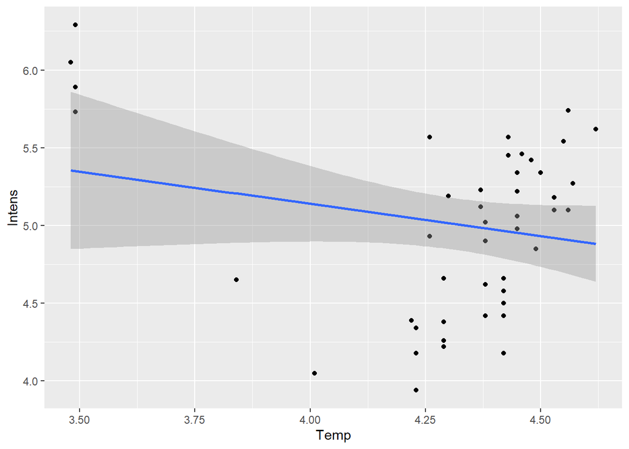

```r
star <- read.table('star.txt', header = TRUE)
ggplot(star, aes(Temp, Intens)) +
  geom_point() +
  geom_smooth(method = lm)
```

Podemos ver que los 4 puntos situados en la esquina superior izquierda desvían la recta de mínimos cuadrados haciendo que genere mucho más error en el resto de puntos del conjunto de datos.

### Apartado B

En lugar de mínimos cuadrados, otro criterio posible para ajustar una regresión es encontrar la recta que minimiza la mediana de los residuos al cuadrado. Esta recta se calcula con el comando MASS::lmsreg de R. Calcula la recta de mínima mediana de cuadrados para los datos de las estrellas. Representa gráficamente la nube de puntos junto con la recta obtenida.

### Solución

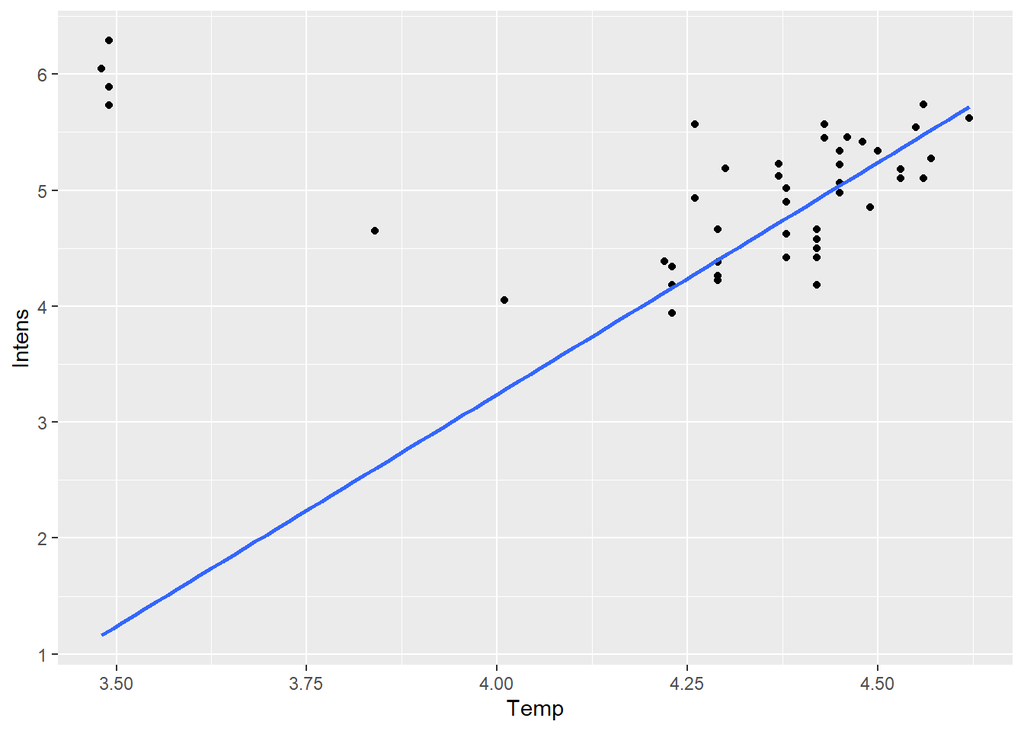

```r
star <- read.table('star.txt', header = TRUE)
ggplot(star, aes(Temp, Intens)) +
  geom_point() +
  geom_smooth(method = function(formula, data, weights=weights) lmsreg(formula, data), se=FALSE)
```

En este caso vemos que la recta ajusta mejor el groso de los datos, pese a que genera mayor error en los puntos de la esquina superior izquierda. Podríamos considerar este tipo de regresión algo más robusta a outliers.

### Apartado C

Usa el método bootstrap para calcular el error típico de la pendiente de la recta de mínima mediana de cuadrados para los datos de las estrellas. ¿Qué problema presenta el método bootstrap para este conjunto de datos concreto?

### Solución

```r
R <- 1000
beta1_boot <- NULL
for (i in 1:R){
  X = sample(star$Temp, 47, rep=TRUE)
  Y = sample(star$Intens, 47, rep=TRUE)
  beta1_boot[i] <- coefficients(lmsreg(Y ~ X))[2]
}
sd(beta1_boot)
```

```
## [1] 0.9929002
```

Vemos que la pendiente es bastante variable según los puntos que escogemos. Esto puede deberse a que, dado que son pocos puntos (sólo 47), al hacer boostrap eliminamos algunos elementos que pueden aportar algo de información.

# Segunda parte

## Selección de variables con datos simulados

### Apartado A

Genera aleatoriamente una variable regresora $X$ y un vector aleatorio $\epsilon$ de longitud $n=100$, con distribución normal estándar e independientes.

### Solución

```r
X <- rnorm(100)
eps <- rnorm(100)
```

### Apartado B

Genera la variable respuesta de acuerdo con el modelo:
$$Y = X + X^2 + X^3 + \epsilon$$
donde $\epsilon$ es una variable normal de media 0 y la varianza que tú elijas.

### Solución

```r
Y <- X + X^2 + X^3 + eps
```

### Apartado C

Selecciona el modelo óptimo entre todos los submodelos que contienen como variables regresoras $X,X^2,X^3,\dots,X^{10}$. ¿Cuál es el mejor modelo de acuerdo con los criterios $C_p$, BIC y $R^2_a$?

### Solución

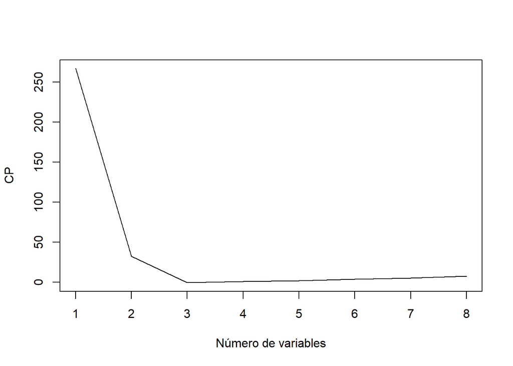

```r
datos <- data.frame(y=Y, x1=X, x2=X^2, x3=X^3, x4=X^4, x5=X^5, x6=X^6, x7=X^7, x8=X^8, x9=X^9, x10=X^10)
modelos <- regsubsets(y~., data=datos)
resumen <- summary(modelos)
plot(resumen$cp, xlab ="Número de variables", ylab="CP", type="l")
```

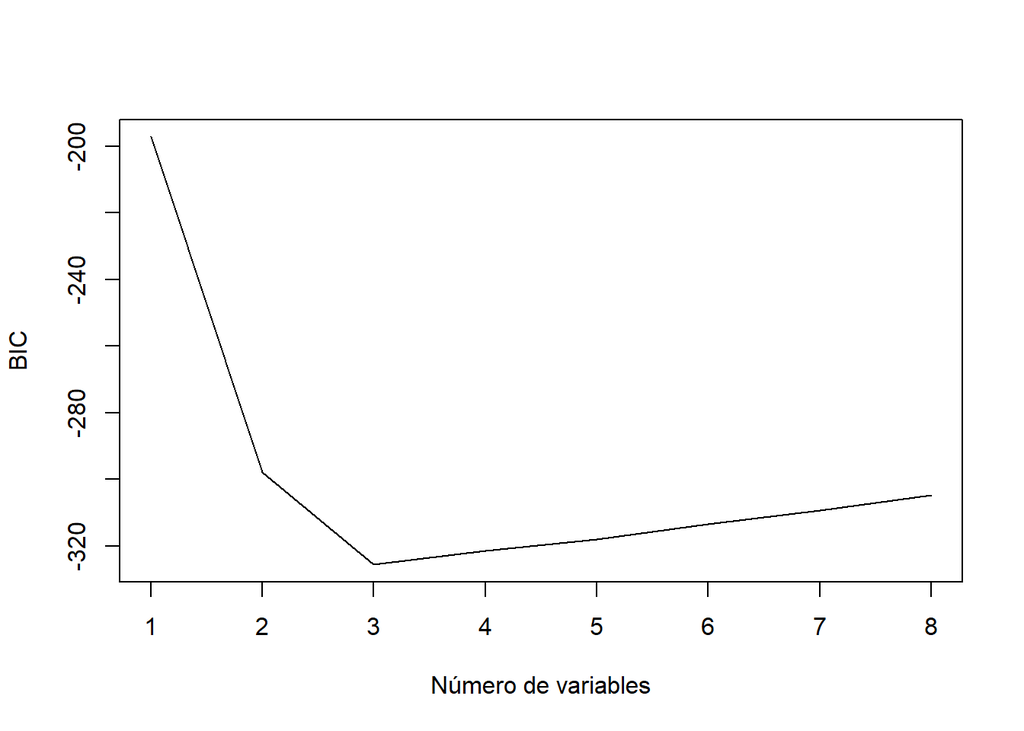

```r
plot(resumen$bic, xlab ="Número de variables", ylab="BIC", type="l")
```

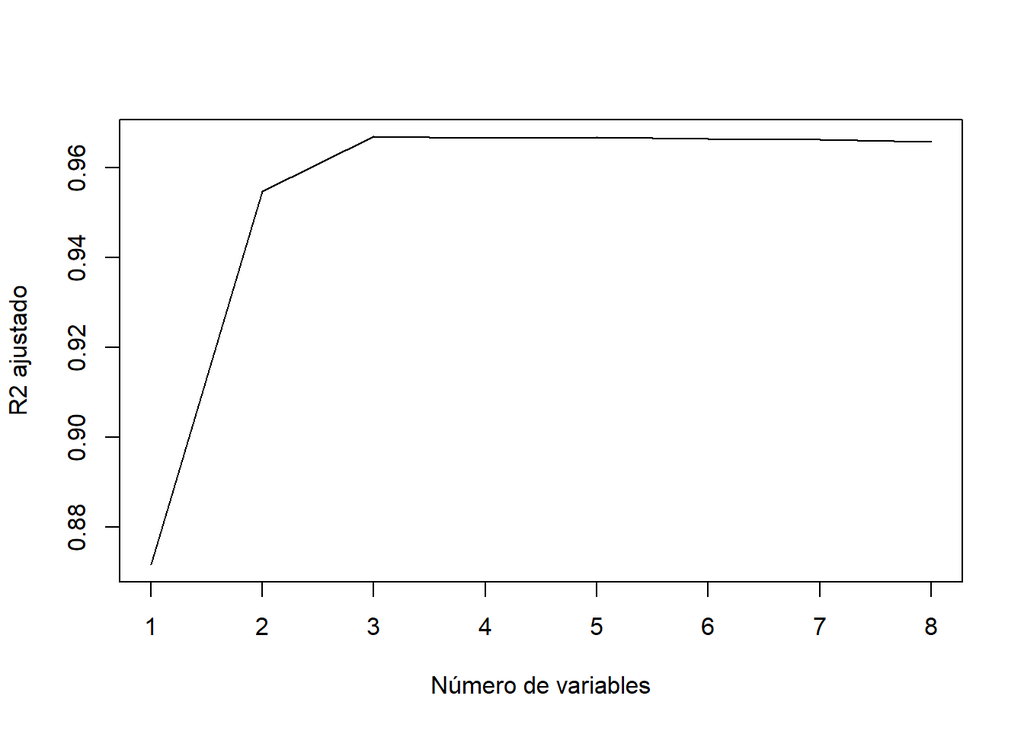

```r
plot(resumen$adjr2, xlab ="Número de variables", ylab="R2 ajustado", type="l")
```

```r
resumen
```

```
## Subset selection object
## Call: regsubsets.formula(y ~ ., data = datos)
## 10 Variables  (and intercept)
##     Forced in Forced out
## x1      FALSE      FALSE
## x2      FALSE      FALSE
## x3      FALSE      FALSE
## x4      FALSE      FALSE
## x5      FALSE      FALSE
## x6      FALSE      FALSE
## x7      FALSE      FALSE
## x8      FALSE      FALSE
## x9      FALSE      FALSE
## x10     FALSE      FALSE
## 1 subsets of each size up to 8
## Selection Algorithm: exhaustive
##          x1  x2  x3  x4  x5  x6  x7  x8  x9  x10
## 1  ( 1 ) " " " " "*" " " " " " " " " " " " " " "
## 2  ( 1 ) " " "*" "*" " " " " " " " " " " " " " "
## 3  ( 1 ) "*" "*" "*" " " " " " " " " " " " " " "
## 4  ( 1 ) "*" "*" "*" "*" " " " " " " " " " " " "
## 5  ( 1 ) "*" "*" " " " " "*" " " "*" " " "*" " "
## 6  ( 1 ) "*" "*" " " " " "*" " " "*" "*" "*" " "
## 7  ( 1 ) "*" "*" " " "*" "*" "*" " " "*" "*" " "
## 8  ( 1 ) "*" "*" " " "*" "*" "*" "*" "*" " " "*"
```

Podemos ver un cambio muy importante de tendencia en todas las gráficas de los criterios a partir 3 variables regresoras. En el resumen, además, comprobamos que las variables utilizadas para este modelo son $X$, $X^2$ y $X^3$, que son las utilizadas para definir $Y$.

### Apartado D

Repite el apartado anterior usando el método iterativo hacia adelante.

### Solución

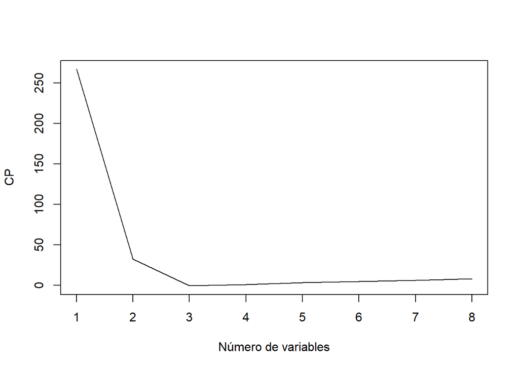

```r
modelos <- regsubsets(y~., data=datos, method="forward")
resumen <- summary(modelos)
plot(resumen$cp, xlab ="Número de variables", ylab="CP", type="l")
```

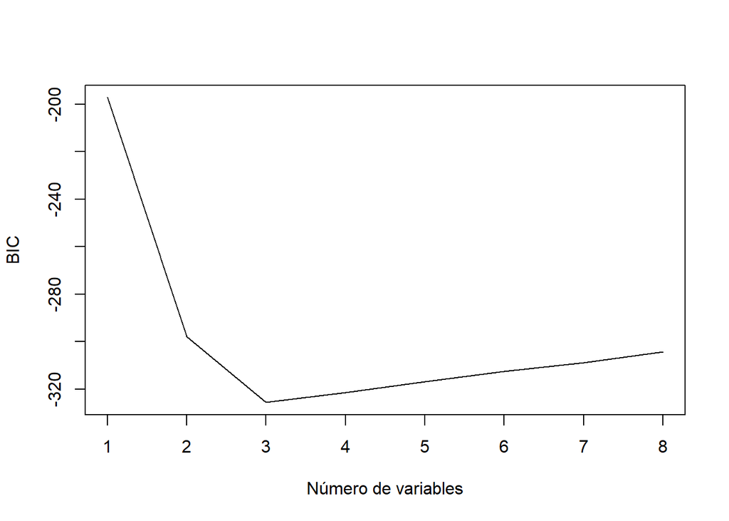

```r
plot(resumen$bic, xlab ="Número de variables", ylab="BIC", type="l")
```

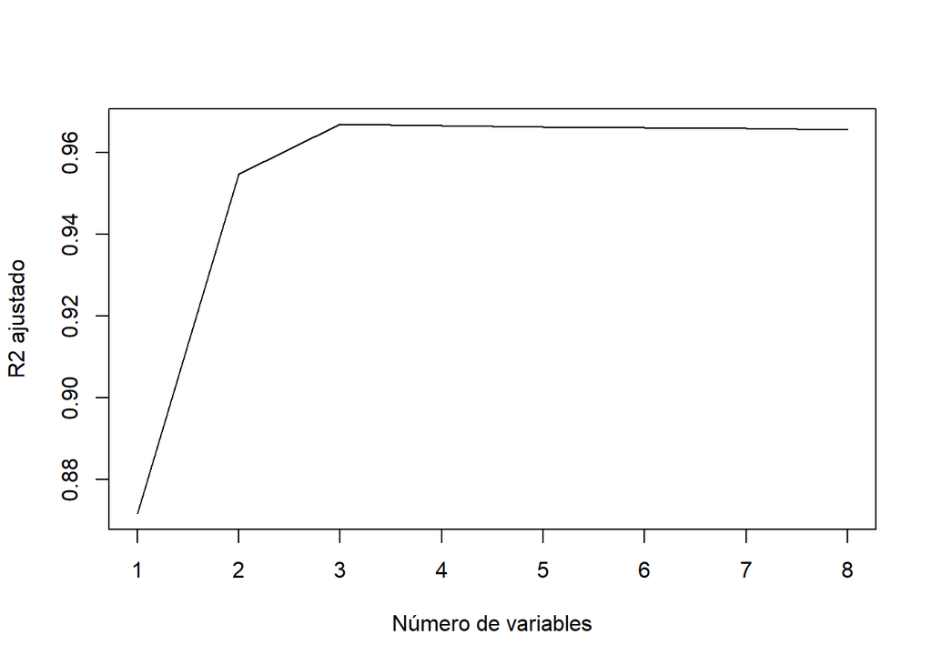

```r
plot(resumen$adjr2, xlab ="Número de variables", ylab="R2 ajustado", type="l")
```

```r
resumen
```

```
## Subset selection object
## Call: regsubsets.formula(y ~ ., data = datos, method = "forward")
## 10 Variables  (and intercept)
##     Forced in Forced out
## x1      FALSE      FALSE
## x2      FALSE      FALSE
## x3      FALSE      FALSE
## x4      FALSE      FALSE
## x5      FALSE      FALSE
## x6      FALSE      FALSE
## x7      FALSE      FALSE
## x8      FALSE      FALSE
## x9      FALSE      FALSE
## x10     FALSE      FALSE
## 1 subsets of each size up to 8
## Selection Algorithm: forward
##          x1  x2  x3  x4  x5  x6  x7  x8  x9  x10
## 1  ( 1 ) " " " " "*" " " " " " " " " " " " " " "
## 2  ( 1 ) " " "*" "*" " " " " " " " " " " " " " "
## 3  ( 1 ) "*" "*" "*" " " " " " " " " " " " " " "
## 4  ( 1 ) "*" "*" "*" "*" " " " " " " " " " " " "
## 5  ( 1 ) "*" "*" "*" "*" " " " " " " " " " " "*"
## 6  ( 1 ) "*" "*" "*" "*" "*" " " " " " " " " "*"
## 7  ( 1 ) "*" "*" "*" "*" "*" " " "*" " " " " "*"
## 8  ( 1 ) "*" "*" "*" "*" "*" "*" "*" " " " " "*"
```

Vemos que en este caso, los resultados son esencialmente los mismos. El modelo que mejor ajusta los datos corresponde con el formado por las variables regresoras $X$, $X^2$ y $X^3$.

### Apartado E

Aplica ahora lasso al modelo que incluye las variables regresoras $X, X^2,\dots,X^{10}$. Selecciona el parámetro de regularización mediante validación cruzada y compara los resultados del ajuste con los de los apartados anteriores.

### Solución

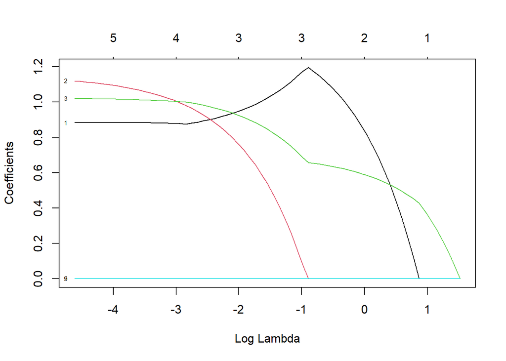

```r
x <- as.matrix(datos[,-1])
y <- datos[,1]
modelo_lasso <- glmnet(x, y, alpha = 1)
plot(modelo_lasso, xvar='lambda', label=TRUE)
```

Vemos que lasso elimina las variables innecesarias con valores de lambda bastante bajos, para buscar el óptimo utilizamos validación cruzada.

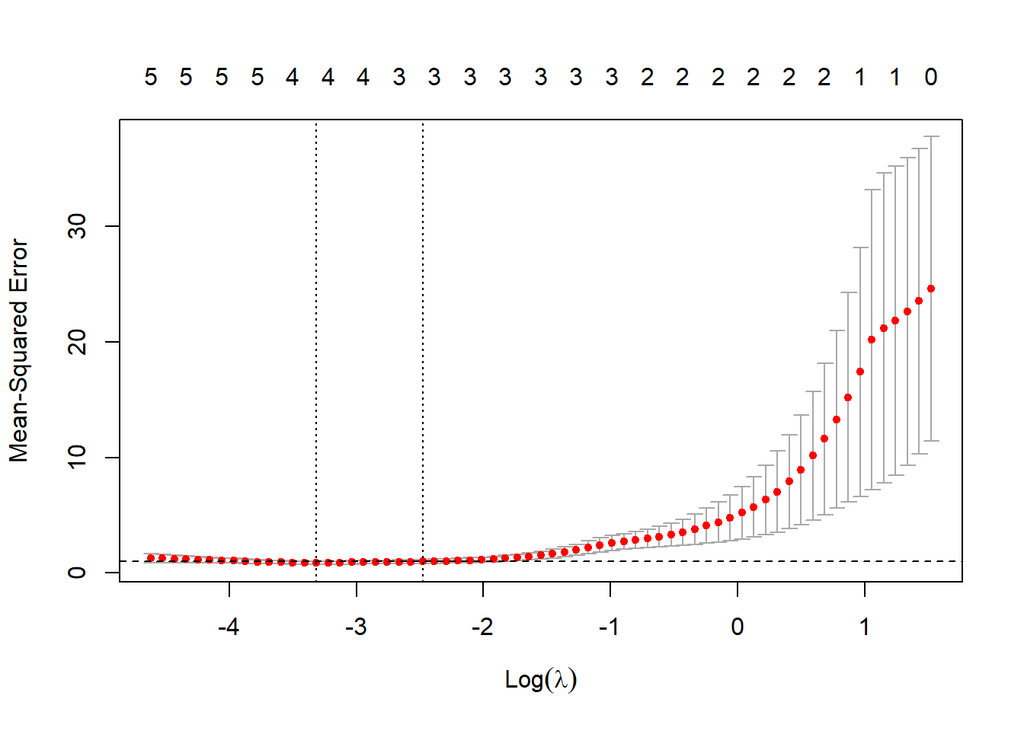

```r
lasso_cv <- cv.glmnet (x, y, alpha = 1)
plot(lasso_cv)
indice <- which(min(lasso_cv$cvm) == lasso_cv$cvm)
abline(h = lasso_cv$cvm[indice] + lasso_cv$cvsd[indice], lty = 2)
```

```r
lambda.lasso = lasso_cv$lambda.1se
```

Vemos que el lambda óptimo es 0.0839996, asi que vamos a representar lasso con ese lambda concreto.

```r
modelo_final_lasso <- glmnet(x, y, alpha = 1, lambda = lambda.lasso)
coef(modelo_final_lasso)
```

```
## 11 x 1 sparse Matrix of class "dgCMatrix"
##                    s0
## (Intercept) 0.1358844
## x1          0.8988882
## x2          0.9060446
## x3          0.9742392
## x4          .
## x5          .
## x6          .
## x7          .
## x8          .
## x9          .
## x10         .
```

Vemos que el modelo con dicho lambda solo tiene en cuenta las variables $X$, $X^2$ y $X^3$.

### Apartado F

Genera ahora las respuestas a partir del modelo

$$Y=X^7 + \epsilon$$
y aplica de nuevo el método lasso.

### Solución

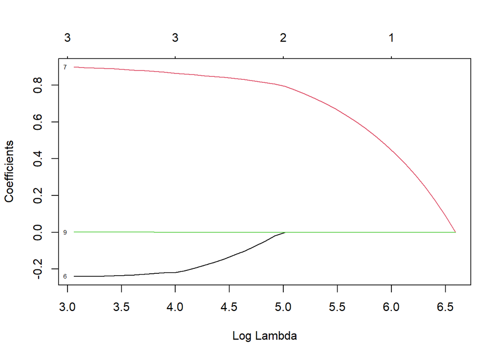

```r
Y <- X^7 + eps
datos <- data.frame(y=Y, x1=X, x2=X^2, x3=X^3, x4=X^4, x5=X^5, x6=X^6, x7=X^7, x8=X^8, x9=X^9, x10=X^10)
x <- as.matrix(datos[,-1])
y <- datos[,1]
modelo_lasso <- glmnet(x, y, alpha = 1)
plot(modelo_lasso, xvar='lambda', label=TRUE)
```

```r
modelo_final_lasso <- glmnet(x, y, alpha = 1, lambda = 20)
coef(modelo_final_lasso)
```

[output not shown]

## Datos de consumo de combustible en EE.UU.

Los datos fuel2001 en el fichero combustible.RData corresponden al consumo de combustible (y otras variables relacionadas) en EE.UU. El siguiente código permite importar los datos a R:

```r
datos <- 'http://verso.mat.uam.es/~joser.berrendero/datos/combustible.RData'
load(url(datos))
head(fuel2001)
```

```
##     Drivers    FuelC Income  Miles      MPC      Pop  Tax
## AL  3559897  2382507  23471  94440 12737.00  3451586 18.0
## AK   472211   235400  30064  13628  7639.16   457728  8.0
## AZ  3550367  2428430  25578  55245  9411.55  3907526 18.0
## AR  1961883  1358174  22257  98132 11268.40  2072622 21.7
## CA 21623793 14691753  32275 168771  8923.89 25599275 18.0
## CO  3287922  2048664  32949  85854  9722.73  3322455 22.0
```

Se desea explicar la variable FuelC en función del resto de la información.

### Apartado A

Representa en un plano las dos primeras componentes principales de estos datos estandarizados (consulta la ayuda de `prcomp`). ¿Son suficientes estas dos componentes para explicar un alto porcentaje de la varianza?

### Solución

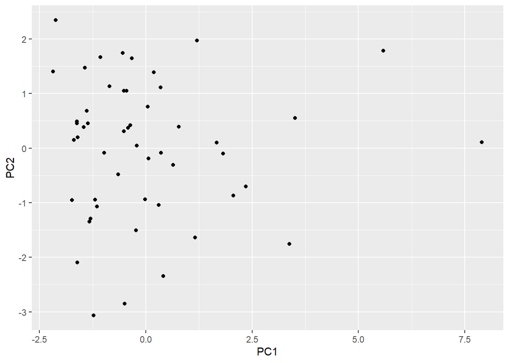

```r
prcomp_fuel <- prcomp(fuel2001, center=TRUE, scale=TRUE)
pca_fuel <- data.frame(
  PC1 = prcomp_fuel$x[,1],
  PC2 = prcomp_fuel$x[,2]
)

ggplot(pca_fuel, aes(x = PC1, y = PC2)) +
  geom_point()
```

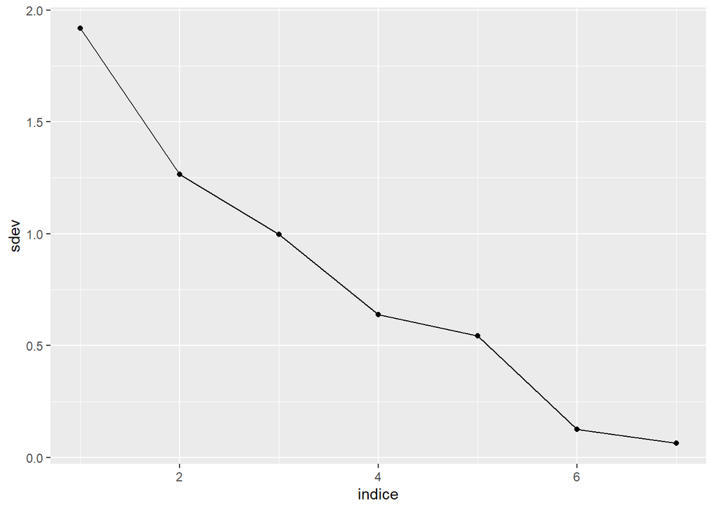

```r
sdev <- data.frame(indice = 1:7,
                   sdev = round(prcomp_fuel$sdev, 3))

ggplot(sdev, aes(x = indice, y = sdev)) +
  geom_line() +
  geom_point()
```

Vemos que con los autovalores de las dos primeras componentes principales están por encima de 1. El autovalor de la tercera componente es 1 y está muy cercano al de la segunda, por ello creo que utilizar sólo las dos primera componentes no explicará la gran parte de la varianza.

### Apartado B

Ajusta el modelo completo con todas las variables. En este modelo completo, contrasta la hipótesis nula de que los coeficientes de las variables `Income`, `MPC` y `Tax` son simultáneamente iguales a cero.

### Solución

```r
modelo <- lm(FuelC ~ ., data=fuel2001)
modelo0 <- lm(FuelC ~ Drivers + Miles + Pop, data=fuel2001)
anova(modelo0, modelo)
```

```
## Analysis of Variance Table
##
## Model 1: FuelC ~ Drivers + Miles + Pop
## Model 2: FuelC ~ Drivers + Income + Miles + MPC + Pop + Tax
##   Res.Df        RSS Df  Sum of Sq      F Pr(>F)
## 1     47 7.8556e+12
## 2     44 6.9843e+12  3 8.7128e+11 1.8296 0.1557
```

Con el contraste anova entre el modelo completo y el reducido, que no utiliza las variables `Income`, `MPC` y `Tax`, podemos ver que el p-valor superior a un $\alpha = 0.05$, por lo que no podemos rechazar el modelo reducido a favor del modelo completo. Con esto, no podemos decir que los coeficientes de las variables `Income`, `MPC` y `Tax` tomen valores distintos de 0.

### Apartado C

De acuerdo con el método iterativo hacia adelante y el criterio BIC, ¿cuál es el modelo óptimo?

### Solución

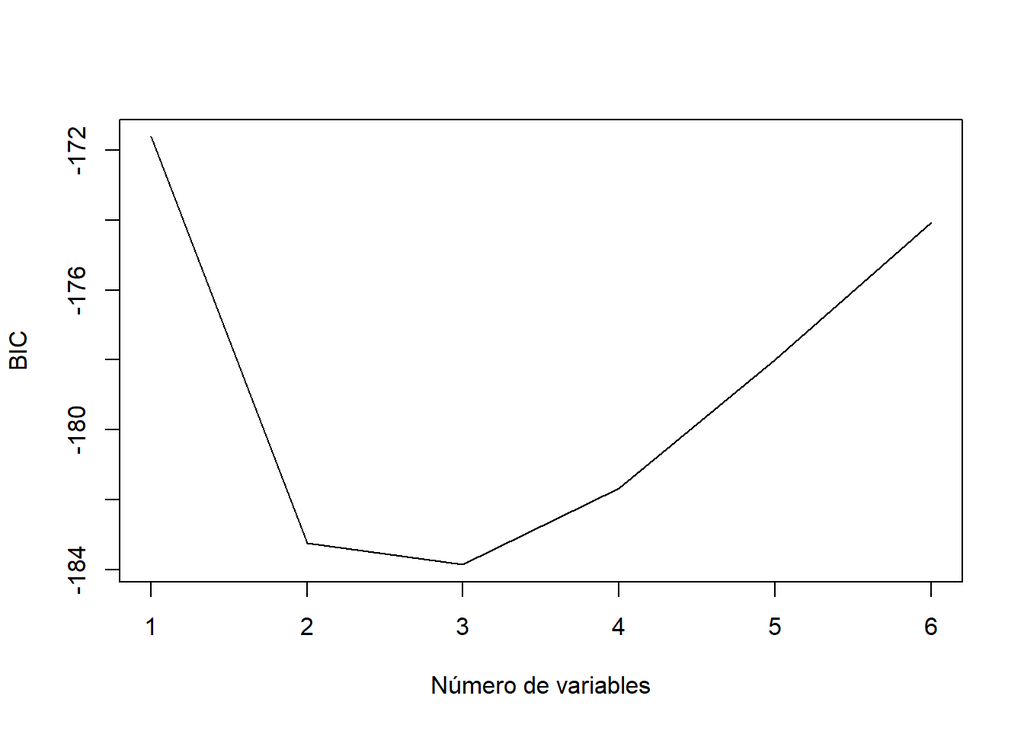

```r
modelos <- regsubsets(FuelC~., data=fuel2001, method="forward")
resumen <- summary(modelos)
plot(resumen$bic, xlab ="Número de variables", ylab="BIC", type="l")
```

```r
resumen
```

```
## Subset selection object
## Call: regsubsets.formula(FuelC ~ ., data = fuel2001, method = "forward")
## 6 Variables  (and intercept)
##         Forced in Forced out
## Drivers     FALSE      FALSE
## Income      FALSE      FALSE
## Miles       FALSE      FALSE
## MPC         FALSE      FALSE
## Pop         FALSE      FALSE
## Tax         FALSE      FALSE
## 1 subsets of each size up to 6
## Selection Algorithm: forward
##          Drivers Income Miles MPC Pop Tax
## 1  ( 1 ) "*"     " "    " "   " " " " " "
## 2  ( 1 ) "*"     " "    "*"   " " " " " "
## 3  ( 1 ) "*"     " "    "*"   " " " " "*"
## 4  ( 1 ) "*"     " "    "*"   "*" " " "*"
## 5  ( 1 ) "*"     "*"    "*"   "*" " " "*"
## 6  ( 1 ) "*"     "*"    "*"   "*" "*" "*"
```

Vemos que el número de variables óptimo es 3 y siguiendo el método iterativo hacia delante se han seleccionado `Drivers`, `Miles` y `Tax`.

### Apartado D

Ajusta el modelo usando lasso, con el parámetro de regularización seleccionado mediante validación cruzada.

### Solución

```r
x <- as.matrix(fuel2001[,-2])
y <- fuel2001[,2]
lasso_cv <- cv.glmnet (x, y, alpha = 1)
lambda.lasso = lasso_cv$lambda.1se
modelo_final_lasso <- glmnet(x, y, alpha = 1, lambda = lambda.lasso)
coef(modelo_final_lasso)
```

```
## 7 x 1 sparse Matrix of class "dgCMatrix"
##                       s0
## (Intercept) 2.292242e+05
## Drivers     5.652140e-01
## Income      .
## Miles       2.502297e+00
## MPC         .
## Pop         .
## Tax         .
```

Vemos que mediante validación cruzada para lasso, el modelo seleccionado coloca las variables `Drivers` y `Miles`.

### Apartado E

Ajusta el modelo usando ridge, con el parámetro de regularización seleccionado mediante validación cruzada.

### Solución

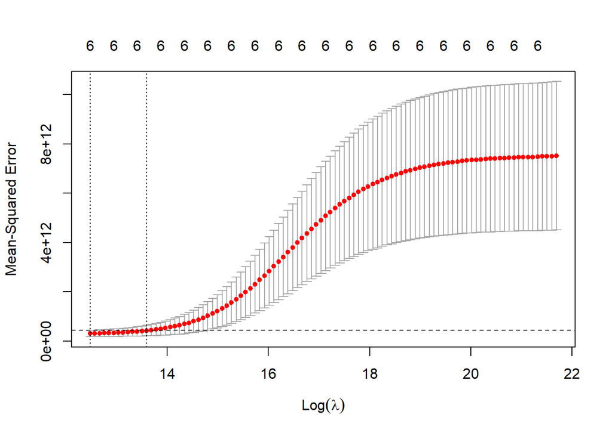

```r
ridge_cv <- cv.glmnet (x, y, alpha = 0)
plot(ridge_cv)
indice <- which(min(ridge_cv$cvm) == ridge_cv$cvm)
abline(h = ridge_cv$cvm[indice] + ridge_cv$cvsd[indice], lty = 2)
```

```r
lambda.ridge = ridge_cv$lambda.1se
modelo_final_ridge <- glmnet(x, y, alpha = 0, lambda = lambda.ridge)
coef(modelo_final_ridge)
```

```
## 7 x 1 sparse Matrix of class "dgCMatrix"
##                        s0
## (Intercept)  1.341364e+05
## Drivers      2.549465e-01
## Income       1.956565e+01
## Miles        9.065070e+00
## MPC         -6.578694e-01
## Pop          2.058081e-01
## Tax         -3.345762e+04
```